# Question

En una entrevista para una podcast de televisi?n, una piloto de un biplano de competici?n comenta en detalle c?mo fue su presentaci?n:

“Durante los primeros 20 segundos aument? la altura de manera constante y, luego, realic? una pirueta en la que descend? de manera constante durante 7 segundos. Despu?s del descenso, comenc? a girar en torno al eje del biplano durante 15 segundos, manteniendo la misma altura. Para finalizar, aterric? reduciendo la altura de manera constante durante 25 segundos”.

?Cu?l de las siguientes gr?ficas representa de forma CORRECTA la informaci?n dada por la piloto?

## Answerlist

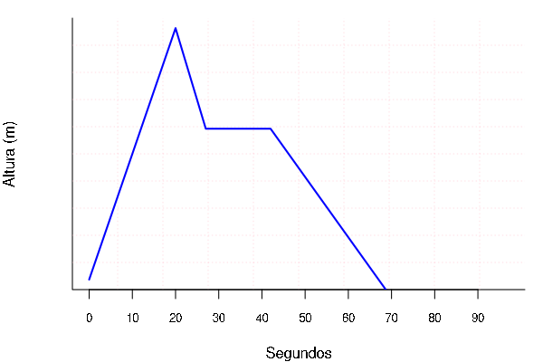

- Opci?n A

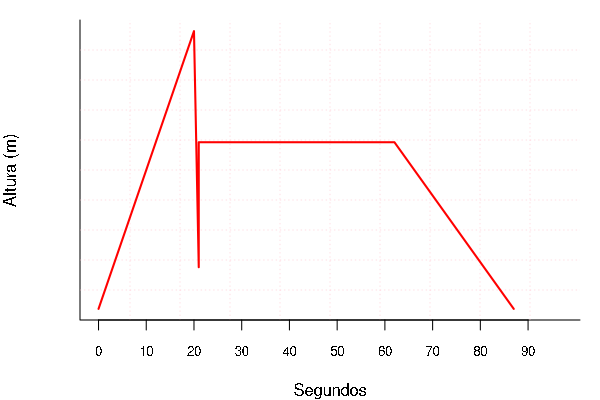

- Opci?n B

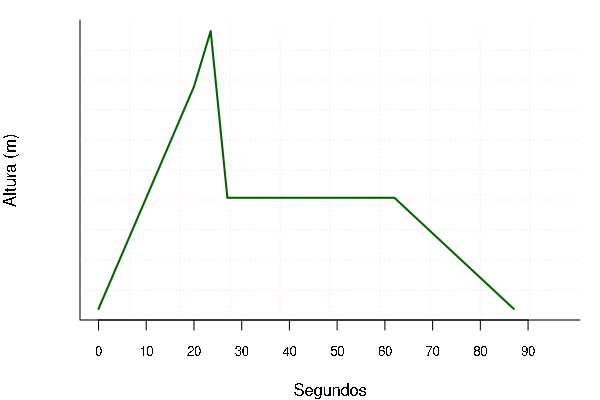

- Opci?n C

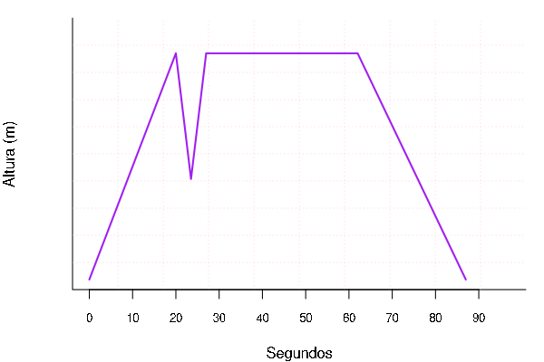

- Opci?n D

# Solution

Debemos analizar las distintas partes del vuelo seg?n la descripci?n dada por la piloto:

Analizando las opciones:

**Opci?n A:** - Subida constante hasta 20 segundos  - Descenso constante por 7 segundos  - Mantiene altura constante durante el giro por 15 segundos  - Descenso constante final por 25 segundos

**Opci?n B:** - Subida constante hasta 20 segundos  - Ca?da brusca (casi vertical)  - Deber?a ser un descenso constante - Mantiene altura constante luego del descenso  - Descenso constante final

**Opci?n C:** - Subida constante hasta 20 segundos  - Sube y luego baja (formando un pico)  - Deber?a ser solo un descenso constante - Mantiene altura constante  - Descenso constante final

**Opci?n D:** - Subida constante hasta 20 segundos  - Baja y luego vuelve a subir  - Deber?a ser solo un descenso constante - Mantiene altura constante  - Descenso constante final

Por lo tanto, la gr?fica que representa correctamente toda la descripci?n del vuelo es la **Opci?n A**.

# Meta-information